Interim Review Report 1 · sections 5 and 11

# Sex codes are correct; the anomaly is midwater trawl

Verification of the numeric sex-code dictionary for Outside Pacific Spiny Dogfish, and disposition of the section 11 run gate.

**To**

Sean Cox

**From**

S.D.N. Johnson, Landmark Fisheries Research

**Date**

25 August 2026

**Subject**

Anderson et al. (2026), DFO CSAS Res. Doc. 2025/055

## Bottom line

The numeric sex codes are correct as used. Code 1 is male and code 2 is female, confirmed against the authoritative DFO data dictionary published on the Government of Canada open data portal. The composition inputs to A0 are not reversed, and the run gate in section 11 can be lifted.

The anomaly you identified is real, but it is not a coding artifact. It is confined to the midwater trawl fleet, where it reads as size-selective availability — and that fleet’s own compositions fit *worse*, not better, when its sexes are reversed, with essentially no spillover to any other fleet. The separate structural concern in the first paragraph of section 5 — whether strongly sex-specific selectivity is necessary — is unaffected by this result, and in our view is the more consequential question.

## What was tested

Your section 5 required audit asked for the sex codes to be traced from raw records through to the SS3 inputs, and for sex-specific means and quantiles to be compared by dataset. The two files you were missing, `survey-samples.rds` and `commercial-samples.rds`, are present in the repository we hold, so the trace could be completed. We also refit the model under the reversal hypothesis to bound its consequence.

## Evidence

### 1 The authoritative dictionary

The DFO *Groundfish Synoptic Bottom Trawl Surveys* record on open.canada.ca (dataset `a278d1af‑d567‑4964‑a109‑ae1e84cbd24a`) publishes a data dictionary that defines the field directly:

> **Sex** — Sex of the fish: 0 = not examined; 1 = male; 2 = female, 3 = unknown

> **Sexe** — 0 non examiné; 1 = mâles, 2 = femelles et 3 = sexe indéterminé

This is the item listed as outstanding in your section 15. It matches the assumption in `ss3/01-outside-stock-synthesis-data.R` line 323 exactly, and is consistent with the code frequencies in the raw file, which include the rare 0 and 3 categories the dictionary describes — 0: 525, 1: 86,783, 2: 62,914, 3: 25, missing: 706.

### 2 The published data reproduce our extraction

The portal also publishes specimen-level biology. Queen Charlotte Sound dogfish records, against the same survey in the repository copy:

Queen Charlotte Sound dogfish, lengths in cm

| Source | sex 1 n | mean | q95 | max | sex 2 n | mean | q95 | max |
| --- | --- | --- | --- | --- | --- | --- | --- | --- |
| Open data portal | 2920 | 70.1 | 85 | 99 | 1531 | 64.4 | 82 | 118 |
| survey-samples.rds | 3156 | 69.9 | 85 | 99 | 1681 | 63.9 | 81 | 118 |

Small count differences reflect usability-code filtering. The two sources agree, so the GFBio extraction is faithful.

### 3 Cross-check against unambiguous character codes

Length by sex, cm

| Source | F mean | F q95 | F max | M mean | M q95 | M max |
| --- | --- | --- | --- | --- | --- | --- |
| IPHC (character codes) | 91.5 | 108 | 122 | 78.1 | 88 | 115 |
| Bottom trawl (code 2 / 1) | 94.1 | 110 | 124 | 78.2 | 91 | 112 |
| Longline (code 2 / 1) | 95.4 | 110 | 128 | 82.3 | 90 | 114 |

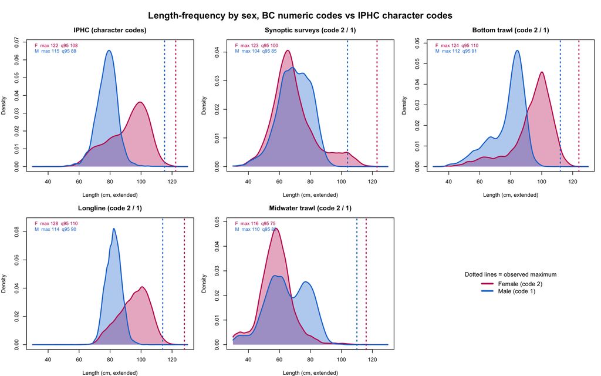

Length-frequency by sex. The IPHC panel (character codes) is the reference. Code 2 reproduces its female profile in bottom trawl and longline; dotted lines mark observed maxima.

### 4 The maxima never invert

Code 2 reaches 116–128 cm in every gear and survey; code 1 tops out at 99–115 cm. A label reversal flips an entire distribution, maximum included. Here the maximum stays with code 2 even in the fleets where its *median* is smaller. That signature is not consistent with a swap. It is consistent with females spanning a wider size range than males, which mature small and stop growing.

### 5 Maturity staging

Sex 1 is almost entirely a single maturity code (90, n = 13,738). Sex 2 carries the full staged ladder — 50–56, 70–79, 95–99 — which is the gestation and uterus-condition staging that exists only for females.

### 6 The reversal fits materially worse

We built `S1_sexswap` by exchanging the 17 female and 17 male bins in all 73 length-composition rows of A0’s `data.ss`, confirmed no other part of the file changed, and refit with the Hessian.

Negative log-likelihood by component

| Component | A0 (as coded) | S1 (swapped) | Change |
| --- | --- | --- | --- |
| Length composition | 671.1 | 1007.8 | +336.7 |
| Survey | 922.5 | 871.5 | −51.0 |
| Parameter priors | 52.7 | 134.8 | +82.1 |
| Total | 1646.4 | 2014.1 | +367.7 |
| Depletion 2023 | 0.086 | 0.076 | — |

The mechanism is visible in the aggregate composition fits. The swap requires large numbers of males at 95–105 cm in the landings fleets, against a male asymptotic length near 84 cm and a female value of 97.4 cm. The model cannot reach that, so the compositions misfit and selectivity is driven hard against its priors — the contortion anticipated in section 5, but appearing in the swapped configuration rather than the base.

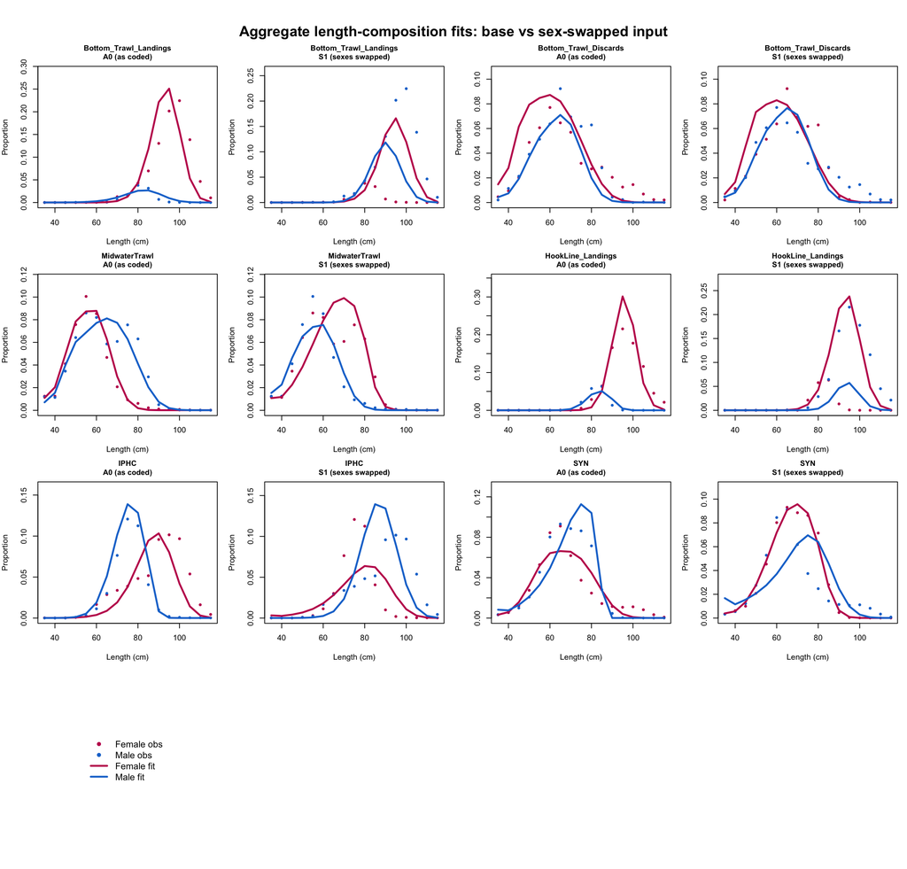

Aggregate composition fits, each fleet shown as base then swapped. The landings fleets are where the swap breaks down: it demands male observations at 95–105 cm that the growth curve cannot supply.

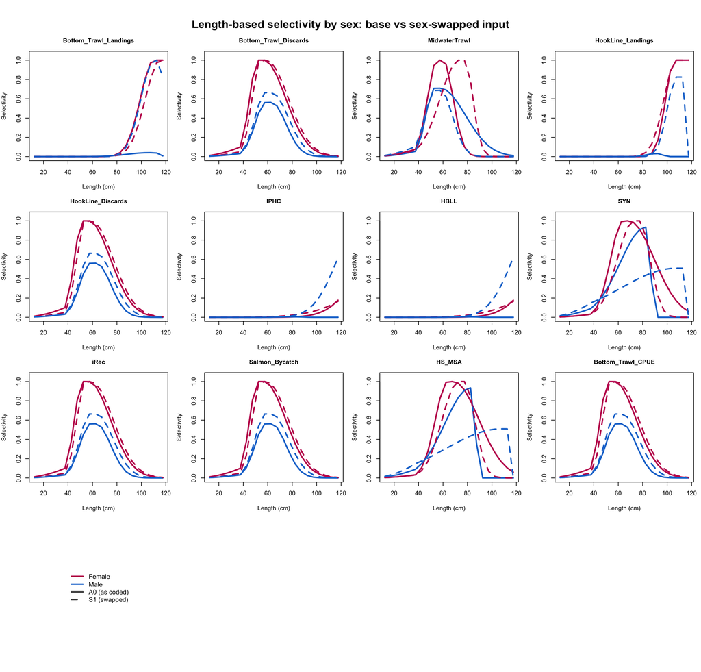

Length-based selectivity. Dashed curves are the swapped configuration, where male selectivity in hook & line landings and SYN takes on shapes that are hard to defend against gear behaviour.

### 7 The direction is inconsistent across fleets

Mean observed length by sex in A0’s own compositions, aggregated over years:

Mean observed length by sex, cm

| Fleet | Mean F | Mean M | F − M | Prop. female |
| --- | --- | --- | --- | --- |
| Bottom Trawl Landings | 95.7 | 80.6 | **+15.1** | 0.90 |
| HookLine Landings | 96.3 | 82.2 | **+14.1** | 0.84 |
| IPHC | 88.9 | 75.6 | **+13.3** | 0.59 |
| Bottom Trawl Discards | 67.0 | 66.0 | +1.0 | 0.49 |
| SYN | 67.2 | 67.7 | −0.5 | 0.46 |
| Midwater Trawl | 56.3 | 63.6 | −7.4 | 0.42 |

Four of six fleets run in the expected direction, three of them by 13–15 cm. Aggregated across years only midwater trawl shows the flagged pattern materially; SYN is −0.5 cm, which is no difference. Individual Synoptic years may still resemble Figures 7 and 9.

This distribution is itself an argument against a coding error, independent of the raw data. A dictionary error is a property of the source system, so it must flip every fleet drawn from that system in the same direction. Midwater trawl and bottom-trawl landings both come from `commercial-samples.rds` and are both numerically coded, yet they run in opposite directions. No dictionary swap can produce that.

### 8 Midwater trawl’s own data reject the swap

The obvious follow-up is whether midwater trawl, the one fleet that shows the pattern materially, fits better when reversed. It does not. We decomposed the length-composition likelihood by fleet, and additionally fit `S2_mwswap`, in which only the 14 midwater trawl rows are exchanged and every other fleet is left as coded.

Length-composition likelihood by fleet, best of 21 starts

| Fleet | A0 (as coded) | All swapped | MW-only swapped |
| --- | --- | --- | --- |
| Bottom Trawl Landings | 34.5 | 128.1 | 34.1 |
| Bottom Trawl Discards | 65.7 | 61.7 | 66.6 |
| Midwater Trawl | 108.1 | 118.5 | 119.6 |
| HookLine Landings | 35.1 | 128.9 | 34.9 |
| IPHC | 168.5 | 289.0 | 169.8 |
| SYN | 259.1 | 281.6 | 257.8 |
| Length-comp total | 671.1 | 1007.8 | 682.7 |
| Total objective | 1646.4 | 2014.1 | 1664.0 |

Midwater trawl is worse under both configurations — 108.1 as coded, 118.5 when every fleet is swapped, 119.6 when it alone is swapped. Under the single-fleet swap the penalty is almost entirely confined to the fleet that was swapped: 11.5 units of a total 11.6-unit change in the length-composition likelihood, with the other five fleets moving by at most 1.3 units either way. The fleet that generated the anomaly is the fleet whose own data most directly reject reversing it.

The single-fleet swap costs 17.6 units in total against A0, on identical data and an identical parameter count — a decisive preference in likelihood terms without being dramatic, and a smaller margin than the global reversal’s 367.7.

## Why these are best-of-21 fits

**This likelihood surface is strongly multi-modal.** Perturbed configurations started from the supplied control values converge, with small maximum gradient components and no parameter at a bound, to optima several hundred units worse than the same configuration started elsewhere — in one case 645 units. Every figure on this page is therefore the best of 21 starts: the supplied values, a warm start from A0’s solution where the parameter vector permits, and 19 seeded jitters. A0 itself is robust; all 21 starts return 1646.38.

The alternative modes are interpretable rather than numerical noise. At the poor SYN optimum the male apex selectivity scale falls from 0.934 to 0.446, so the model explains the same sex composition by deciding the survey barely catches males. That the data admit both readings is independent support for the section 5 concern that sex-specific selectivity is weakly identified — and it means no section 10 diagnostic can be read from a single fit.

## What the anomaly actually is

Female dogfish span roughly 40 to 120+ cm. Males compress into a narrow adult band near 70–90 cm. In gear that catches predominantly juveniles the female mode therefore sits *below* the male mode while the female tail still extends far above it. Midwater trawl is the clear case: female mode near 58 cm against a male mode near 78 cm, with female maximum 116 cm against male 110 cm. This is size structure and availability — the branch anticipated in your section 12.

## Disposition

- The section 11 run gate can be lifted. Compositions do not need rebuilding.
- The section 15 request for the authoritative sex-code dictionary is closed; the source is public and cited above.
- The section 5 structural question is untouched by this result. We note that in A0, male selectivity in both Bottom Trawl Landings and HookLine Landings is effectively zero — the model attributes landed catch almost entirely to females. That is a strong claim resting on sex-specific selectivity, and we suggest it is the higher-value target for the bounded diagnostic programme in section 10.

## Reproduction status

The items listed as missing in section 11 have been reconstructed:

- SS3 v3.30.22.1 (`ss3_opt_osx_arm64`, SHA-256 `38870aa0…f756ea5dc5`), pinned and fetched by script.
- All 21 A- and B-series configurations refit and converged, maximum gradient 1e‑8 to 1.6e‑3.
- A0 reproduces the published base depletion: 0.086, standard deviation 0.005, against a published value of 0.09 with CI 0.08–0.09.
- A8 (HBLL only) returns depletion 0.997 with zero standard deviation and unfished spawning output of 1.08×10<sup>7</sup>. It appears to carry no scale information and should not be weighted in an ensemble.
- The R environment is pinned in an `renv.lock` — 230 packages, dated CRAN snapshot, GitHub packages pinned by commit.

## Outstanding data request

The one remaining gap is the midwater trawl biological samples, which are commercial rather than survey data and so are not on the open portal. A separate request has been drafted. Coverage in the copy we hold is 27,933 dogfish specimens with sex and length, sampling description UNSORTED, 1979–2019, across 257 distinct samples — 18,741 of them in the 1990s, so a small number of sampling events may dominate the pattern.

Analysis scripts and figures: review/01-sex-code-audit.R, review/02-sexswap-fits.R. Swapped model configuration: ss3/S1_sexswap/.